# Ecology Journal Bias

## Installing packages used

```r
#install.packages("vctrs")
#install.packages("ggplot2",repos = c("http://rstudio.org/_packages","http://cran.rstudio.com"))
library(ggplot2)
#install.packages("gplots")
library(gplots)
#install.packages("mosaic")
library(mosaic)
#install.packages("usmap")
library(usmap)
#install.packages("RColorBrewer")
library(RColorBrewer)
#install.packages("dplyr")
library(dplyr)
#install.packages("mosaic")
library(mosaic)
#install.packages("mosaicCore")
library(mosaicCore)
```

# New Matrix of data

```r
#our data is only 175 lines long
EcologyBias <- EcologyBias_Daneshgar_Popo_2_[1:175, ]
EcologyBias # the name of our new matrix with all the data
```

# Contingency tables

## Contingency table: Contient where the work was done

```r
continent.work <- as.vector(EcologyBias$`Continent where work done`) # removing the column of all the continents where the work was done and making it into a vector

remove <- c ("Europe & Oceania", "META ANALYSIS","META ANALYSIS!") # removing these variables because it goes against the assumptions of a chisq test (mutually exclusive & independent)

# (continent.work %in% remove) ---> creates a vector of TRUE and FALSE to remove the elements we do not want
continent.work <- continent.work [! continent.work %in% remove] # continent.work now has mutually exclusive and independent elements but contains NAs

continent.work[43] <- "Oceania" # fixing a miss spelling error
continent.work[61] <- "Oceania" # fixing a miss spelling error

continent.work <- c(continent.work[1:97], continent.work[99:168]) # removing NAs
# continent.work is not clean
# I made a vector with all the continents and excluded the NAs

continent <- as.matrix(table(continent.work))
continent
```

# Case 1

## Chi-Square: Country where the work was done

```r
# Running Chi-Sq After removing Multiples

# Making the column for country into a vector
country.work <- as.vector(EcologyBias$`Country where the work is done`)

# Printing the vector to look for the multiples we need to remove
country.work

# Creating a vector of the data names of what we need to remove
remove <- c ("US and Mexico","Multiple???", "META ANALYSIS")

# %in% returns a boolean TRUE if it is in remove, false if not
country.work %in% remove

# Removing everything in the remove vector from country.work
country.work <- country.work [! country.work %in% remove]

#Printing the vector to make sure we didn't miss anything
country.work

# This is changing 1-5 and 8-11 from US to USA so everything matches
country.work[1:5] <- "USA"
country.work[8:11] <- "USA"

# Printing the vector to make sure it worked properly
country.work

# Removing any NA
country.work <- country.work[!is.na(country.work)]

# Printing the vector to make sure it worked properly
country.work

# Rerunning the contingency table to to look at the new counts
tally(country.work)

# Running the chi-squared on the new data
chisq.test(tally(country.work))
```

A contingency table was made to look at the number of journal articles, based off of the country that the work for the article was done. The highest number of articles were from the United States, where there were 68 journal articles. The majority of the other countries only had one or two journal articles from each. From the chi-squared test shows that the probability of each country being represented in a journal entry is not the same $(P<2.2e-16)$.

## Chi-Square: Region where the work was done

```r
# Making the column for region into a vector
region.work <- as.vector(EcologyBias$`Regions where the work was done  (Popo defines)`)

# Printing the vector to look for the multiples we need to remove
region.work

# Creating a vector of the data names of what we need to remove
remove <- c ("Multiple", "META ANALYSIS", "Multiple Ranges")

# %in% returns a boolean TRUE if it is in remove, false if not
region.work %in% remove

# Removing everything in the remove vector from region.work
region.work <- region.work [! region.work %in% remove]

#Printing the vector to make sure we didn't miss anything
region.work

# Removing any NA
region.work <- region.work[!is.na(region.work)]

# Printing the vector to make sure it worked properly
region.work

# Rerunning the contingency table to to look at the new counts
tally(region.work)

# Running the chi-squared on the new data
chisq.test(tally(region.work))
```

A contingency table was made to look at the number of journal articles, based off of the region that the work for the article was done. The highest number of articles were from the Pacific, where there were 24 journal articles. The lowest number of journal articles were from the North-West and Mid-South, which had 1 journal article each. The chi-squared test shows that the probability of each country being represented in a journal entry is not the same $(P<3.171e-11)$.

## Chi-Square: State where the work was done

```r
# Making the column for state into a vector
state.work <- as.vector(EcologyBias$`State or Municipality where the work was done`)

# Creating a vector of the data names of what we need to remove
remove <- c ("Multiple States", "Multiple", "META ANALYSIS", "OR/CA", "GA/FL", "NY, MA, CT")

# Removing everything in the remove vector from state.work
state.work %in% remove
state.work <- state.work [! state.work %in% remove]

# Removing any NA
state.work <- state.work[!is.na(state.work)]

# Rerunning the contingency table to to look at the new counts
tally(state.work)

# Running the chi-squared on the new data
chisq.test(tally(state.work))
```

A contingency table was made to look at the number of journal articles, based off of the state in the United States that the work for the article was done. The highest number of articles were from California, where there were 13 journal articles. The majority of the other states only had one or two journal articles from each. From the chi-squared test shows that the probability of each state being represented in a journal entry is not the same $(P<3.284e-05)$.

## Chi-Square: Ecosystem (Marine, Terrestrial, Freshwater, Mixed)

```r
# Making the column for ecosystem into a vector
ecosystem.MTF <- as.vector(EcologyBias$`Marine, Terrestrial, Freshwater, Mixed`)

# Printing the vector to look for data names we need to remove
ecosystem.MTF

# Creating a vector of the data names of what we need to remove
remove <- c ("Mixed")

# Removing everything in the remove vector from ecosystem.MTF
ecosystem.MTF %in% remove
ecosystem.MTF <- ecosystem.MTF [! ecosystem.MTF %in% remove]

# Removing any NA
ecosystem.MTF <- ecosystem.MTF [!is.na(ecosystem.MTF)]

# Rerunning the contingency table to to look at the new counts
tally(ecosystem.MTF)

# Running the chi-squared on the new data
chisq.test(tally(ecosystem.MTF))
```

A contingency table was made to look at the number of journal articles, based off of whether the research was done in freshwater, marine, or terrestrial. The highest number of articles were from terrestrial, where there were 127 journal articles. The lowest number of journal articles were from freshwater, with 12 journal articles. From the chi-squared test shows that the probability of each ecosystem being represented in a journal entry is not the same $(P<2.2e-16)$.

# Chi-squared test: Continent where the work was done

```r
tally(continent.work)

xchisq.test(tally(continent.work))
# we cannot use the pvalue because the test assumes randomness (our data is not random)
# we can use the observed frequency, expected frequency, and the pearson residual to show that all the continents are not equally represented
```

North America has the most positive residual thus the observed frequency of journal entries exceeded the expected frequency. Australia has the most negative residual thus the observed frequency of journal entries did not meet the expected frequency.

```r
par(mfrow=c(1,2))

mypalette<-brewer.pal(7,"BuGn") # this uses a package to change the color pallet

# what we expect the pie chart to look like based off of our expected values in chisq test
slicesExp <- rep(23.86, length.out = 7)
lbls <- c("Africa ", "Asia","Australia ", "Europe ","North America ","Oceania","South America"  )
pie(slicesExp, labels = lbls, main = "Pie Chart of Continent EXPECTED", col = mypalette )

# what we the pie chart actually looks like based off of our observed values in chisq test
slicesExp <- c(tally(continent.work))
lbls <- c("Africa ", "Asia","Australia ", "Europe ","North America ","Oceania","South America"  )
pie(slicesExp, labels = lbls, main = "Pie Chart of Continent OBSERVED" , col = mypalette)
```

# Case 2

## Chi-squared test: Continent where the work was done

```r
sm.continent <- c(SqrMileage$`Sq. mi (million mi^2)`) # data of the sqr mileage for each continent in a vector
sm.continent <- as.numeric(sm.continent[2:8]) # making a numerical vector (was a string before)
prop.cont <- sm.continent/sum(sm.continent) # the proportion we expect each continent to follow based off of its sqr mileage
# we set p = prop.cont since we are niw assuming the observed frequency should match the proportion of its sqr mileage

xchisq.test(tally(continent.work),p=prop.cont )
# we cannot use the pvalue because the test assumes randomness (our data is not random)
# we can use the observed frequency, expected frequency, and the pearson residual to show that all the continents are not represented basded off of their sqr mileage
```

```r
par(mfrow=c(2,1))
E <- c(35.26, 51.73, 8.93, 11.82, 28.67 ,9.89 ,20.70)
CS <- c("Africa", "Asia", "Aust", "Europe", "NA", "Oceania", "SA")
barplot(E, names.arg = CS, xlab ="Country", ylab = " # of Journals", col = "blue", main = "Expected # of Journals in each Continent based on the Sq. Mileage", border = "black")

O <- c(5,14,2,34,94,5,13)
C <- c("Africa", "Asia", "Aust", "Europe", "NA", "Oceania", "SA")
barplot(O, names.arg = C, xlab ="Country", ylab = " # of Journals", col = "blue", main = "Observed # of Journals in each Country based on Sqr. Mileage", border = "black")
```

## Chi-Square: Country where the work was done

```r
country.work <- as.vector(EcologyBias$`Country where the work is done`) # removing the column of country where the work was done and making it into a vector

remove <- c ("Brazil/Costa Rica/Puerto Rico", "Germany & New Zealand","Lesser Antilles/Guadelupe", "META ANALYSIS", "Multiple???", "US and Mexico", "Trinidad and Tobago") # removing these variables because it goes against the assumptions of a chisq test (mutually exclusive & independent)

# (continent.work %in% remove) ---> creates a vector of TRUE and FALSE to remove the elements we do not want
country.work <- country.work [! country.work %in% remove] # country.work now has mutually exclusive and independent elements but contains NAs

country.work[1:5] <- "USA" # fixing a spelling error
country.work[8:11] <- "USA" # fixing a spelling error

country.work <- c(country.work[1:25], country.work[27:34], country.work[36:77], country.work[79:95], country.work[97:121], country.work[123:144], country.work[146:168]) # removing NAs
# country.work is not clean
# I made a vector with all the countries and excluded the NAs

country <- as.matrix(table(country.work))
country
```

# Case 1

## Chi-squared test: Country where the work was done

```r
xchisq.test(tally(country.work), simulate.p.value=TRUE)
# we cannot use the pvalue because the test assumes randomness (our data is not random)
# we can use the observed frequency, expected frequency, and the pearson residual to show that all the countries are not equally represented
# we are setting simulate.p.value = TRUE because we have MANY categories
```

## Contingency table: Region where the work was done

```r
region.work <- as.vector(EcologyBias$`Regions where the work was done  (Popo defines)`)# removing the column of region where the work was done and making it into a vector

remove <- c ("Multiple", "META ANALYSIS", "Multiple Ranges")# removing these variables because it goes against the assumptions of a chisq test (mutually exclusive & independent)

# (region.work %in% remove) ---> creates a vector of TRUE and FALSE to remove the elements we do not want
region.work <- region.work [! region.work %in% remove] # region.work now has mutually exclusive and independent elements but contains NAs

region.work <- region.work[!is.na(region.work)] # removing NAs

region <- as.matrix(table(region.work))
region
```

# Case 1: Without Square Mileage

## Chi-squared test: Region where the work was done

```r
xchisq.test(tally(region.work))
# we cannot use the pvalue because the test assumes randomness (our data is not random)
# we can use the observed frequency, expected frequency, and the pearson residual to show that all the regions are not equally represented
```

```r
par(mfrow=c(1,2))

region.col<-brewer.pal(7,"PuBuGn") # this uses a package to change the color pallet

# what we expect the pie chart to look like based off of our expected values in chisq test
Region.Obs <- c(6.70,6.70,6.70,6.70,6.70,6.70,6.70, 6.70, 6.70, 6.70)
R.names <- c("E.NC", "Mid-A", "Mid-S", "Mt", "NE", " NW", "PT", "S.Atl", "W.NC", "W.SC")
pie(Region.Obs, labels = R.names, main="Pie Chart of Region (Expected)", col = region.col)

# what we the pie chart actually looks like based off of our observed values in chisq test
Region.Obs <- c(7,3,1,12,3,1,24, 10, 3, 3)
R.names <- c("E.NC", "Mid-A", "Mid-S", "Mt", "NE", " NW", "PT", "S.Atl", "W.NC", "W.SC")
pie(Region.Obs, labels = R.names, main="Pie Chart of Region (Observed)", col=region.col)
```

# Case 2: With Square Mileage

## Chi-squared test: Region where the work was done

```r
sm.region <- c(SqrMileage$`Sq. mi2 (mi^2)`)# data of the sqr mileage for each region in a vector

sm.region <- as.numeric(sm.region[1:9])# we were only able to find the sqr mileage for 9 regions so we took out the 10th region

prop.region <- sm.region/sum(sm.region)# the proportion we expect each region to follow based off of its sqr mileage
# we set p = prop.regiont since we are now assuming the observed frequency should match the proportion of its sqr mileage

xchisq.test(tally(region.work)[1:9],p=prop.region, simulate.p.value = TRUE)
```

```r
par(mfrow=c(2,1))

# what we expect the bar graph to look like based expected values in chisqr test
RegionSM.Exp <- c(5.54,3.54,15.85,1.33,0.10,16.58,5.42, 9.41, 8.23)
Region <- c("E.NC", "MA",  "Mt", "NE", " NW", "PT", "S.Atl", "W.NC", "W.SC")
barPlot1 <- barplot(RegionSM.Exp, names.arg = Region, xlab ="Region", ylab = " # of Journals", col = "dark green", main = "Expected # of Journals in each Region based on Sqr. Mileage", border = "black")

# what the pie chart looks like based off our observed value in chisqr test
RegionSM.Obs <- c(7,1,12,3,1,24, 10, 3, 3)
Region <- c("E.NC", "MA",  "Mt", "NE", " NW", "PT", "S.Atl", "W.NC", "W.SC")
barPlot1 <- barplot(RegionSM.Obs, names.arg = Region, xlab ="Region", ylab = " # of Journals", col = "dark green", main = "Observed # of Journals in each Region based on Sqr. Mileage", border = "black")
```

## Contingency table: State where the work was done

```r
state.work <- as.vector(EcologyBias$`State or Municipality where the work was done`)# removing the column of state where the work was done and making it into a vector

remove <- c ("Multiple States", "Multiple", "META ANALYSIS", "OR/CA", "GA/FL", "NY, MA, CT")# removing these variables because it goes against the assumptions of a chisq test (mutually exclusive & independent)

# (state.work %in% remove) ---> creates a vector of TRUE and FALSE to remove the elements we do not want
state.work <- state.work [! state.work %in% remove]# state.work now has mutually exclusive and independent elements but contains NAs

state.work <- state.work[!is.na(state.work)] # removing NAs

state <- as.matrix(table(state.work))
state <- state[-22,] # removing Puerto Rico we did not take this state into account (only the 50 states)
# we only have 26 states so I will make a vector that has zeros for the 24 states that were never mentioned (we need all 50 states in order to compare them all by sqr mileage)
missing.states <- rep(0, length.out=24)
total.state.counts <- c(state,missing.states)

state
```

# Case 2

## Chi-squared test: State where the work was done

```r
sm.state <- c(SquareMileage$stateSQM[1:50]) # data of the sqr mileage for all 50 states in a vector

prop.state <- sm.state/sum(sm.state)# the proportion we expect each state to follow based off of its sqr mileage
# we set p = prop.state since we are niw assuming the observed frequency should match the proportion of its sqr mileage

xchisq.test(total.state.counts,p=prop.state, simulate.p.value = TRUE )
# we cannot use the pvalue because the test assumes randomness (our data is not random)
# we can use the observed frequency, expected frequency, and the pearson residual to show that all the states are not represented based off of their sqr mileage
```

```r
library(usmap)
data.states <- as.data.frame(matrix(data=c(SquareMileage$state.In.Order[1:50], SquareMileage$SM.IN.ORDER[1:50]), nrow=50, ncol=2)) # this package takes a data frame the first column are the states and the second column is the square mileage for that state (in the excel sheet it is in order from greatest to least)

colnames(data.states)[1] <- "state" # naming the first column state
colnames(data.states)[2] <- "level" # naming the second column level

# this package cannot take large numbers and put them in order so I assigned 9 levels
# level 1 means the lowest sqr mileage
# level 9 means the highest sqr mileage
data.states[1:6,2] <- 9
data.states[7:12,2] <- 8
data.states[13:18,2] <- 7
data.states[19:24,2] <- 6
data.states[25:30,2] <- 5
data.states[31:36,2] <- 4
data.states[37:42,2] <- 3
data.states[43:48,2] <- 2
data.states[49:50,2] <- 1

data.counts <- as.data.frame(matrix(data=c(SquareMileage$`U.S. States`[1:26], SquareMileage$Counts[1:26]), nrow=26, ncol=2)) # this package takes a data frame the first column are the states in the same order as the contintengency table and the second column is the counts (the number of times a state appeard)
# only 26 rows because we only had counts for 26 states
colnames(data.counts)[1] <- "state" # naming the first colum state
colnames(data.counts)[2] <- "counts" # naming the second column count

par(mfrow=c(1,2))
# map of what we expect the frequency to look like based off of sqr mileage
plot_usmap(data = data.states, values="level", color="black")+theme(legend.position = "right")
# map of the observed frequency
plot_usmap(data = data.counts, values="counts", color="black")+theme(legend.position = "right")
```

## Contingency table: Ecosystems (Marine, Terrestrial, Freshwater)

```r
eco.po <- as.vector(EcologyBias$`Marine, Terrestrial, Freshwater, Mixed`)# removing the column of ecosystem based on (marine, terrestrial, freshwater) and making it into a vector

remove <- c ("Mixed") # removing the mixed option because it goes against the assumptions of a chisq test (mutually exclusive & independent)

# (eco.po %in% remove) ---> creates a vector of TRUE and FALSE to remove the elements we do not want
eco.po <- eco.po [! eco.po %in% remove] # eco.po now has mutually exclusive and independent elements

eco.po <- as.matrix(table(eco.po))

eco.po
```

# Case 1

## Chi-squared test: Ecosystems

```r
xchisq.test(eco.po)
# we cannot use the pvalue because the test assumes randomness (our data is not random)
# we can use the observed frequency, expected frequency, and the pearson residual to show that all the ecosystems are not equally represented
```

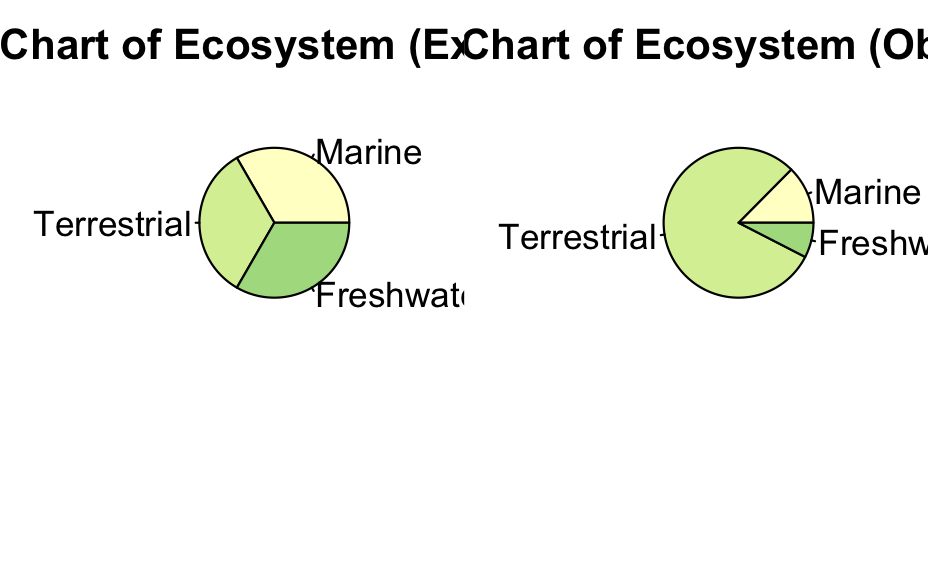

```r
par(mfrow=c(1,2))
eco.col<-brewer.pal(7,"YlGn") # this uses a package to change the color pallet

slices.exp <- c(53,53,53)
lbls <- c("Marine", "Terrestrial", "Freshwater")
pie(slices.exp, labels = lbls, main="Pie Chart of Ecosystem (Expected)", col=eco.col)

slices <- c(20,127,12)
pie(slices, labels = lbls, main="Pie Chart of Ecosystem (Observed)", col = eco.col)
```

# Case 2

## Chi-squared test: Ecosystems

```r
prop.ecosystem <- c(EcoSqrMileage$`Percent Coverage`)


xchisq.test(eco.po,p=prop.ecosystem, simulate.p.value = TRUE )
# we cannot use the pvalue because the test assumes randomness (our data is not random)
# we can use the observed frequency, expected frequency, and the pearson residual to show that all the ecosystems are not equally represented
```

```r
par(mfrow=c(1,2))
e.col<-brewer.pal(7,"Blues") # this uses a package to change the color pallet

slicesExp <- c(111.30,44.36,3.34)
lbls <- c("Marine", "Terrestrial", "Freshwater")
pie(slicesExp, labels = lbls, main="Pie Chart of Ecosystem (Expected)",col=e.col)

slices <- c(20,127,12)
pie(slices, labels = lbls, main="Pie Chart of Ecosystem (Observed)", col = e.col)
```